Скрипин Антон Вадимович ГРУППА: ФТ-360008

# Лабораторная - Преступление в Сан-Франциско - Вариант "A"

### Задачи

Продемонстрируйте свои знания о Data Analysis Lifecycle с использованием заданного набора данных и с применением инструментов Python и Jupyter Notebook

#### Часть 1: Импорт Python пакетов

#### Часть 2: Загрузка данных

#### Часть 3: Подготовка данных

#### Часть 4: Анализ данных

#### Часть 5. Визуализация данных

### История / Cценарий

В этой лабораторной работе вы импортируете некоторые пакеты Python, необходимые для анализа набора данных, которые содержат в себе информацию о преступлениях в Сан-Франциско. Затем при помощи Python и Jupyter Notebook вы подготовите эти данные для анализа, проанализируете их, построите графики, и поделитесь своими результатами.

### Необходимые ресурсы

- 1 ПК с доступом в Интернет
- Raspberry Pi версии 2 или выше
- Библиотеки Python: pandas, numpy, matplotlib, folium, datetime, и csv
- Файл данных: Map-Crime_Incidents-Previous_Three_Months.csv

## Часть 1: Импорт Python пакетов

В этой части вы импортируете следующие пакеты Python, необходимые для остальной части этой лабораторной работы.

#### numpy

NumPy - это фундаментальный пакет для научных вычислений в Python. Он содержит, среди прочего, мощный инструмент для создания N-мерных массивов и сложные (широковещательные) функции.

#### pandas

Pandas - библиотека с открытым исходным кодом, лицензированная BSD, предоставляющая высокопроизводительные, простые в использовании структуры данных и инструменты анализа данных для языка программирования Python.

#### matplotlib

Matplotlib - это графическая библиотека для языка программирования Python и его расширения NumPy.

#### folium

Folim - это библиотека для создания интерактивной карты.

```python
# Ячейка для кода № 1
%matplotlib inline
import numpy as np
import pandas as pd
import matplotlib.pyplot as plt
import folium
```

## Часть 2: Загрузка данных

В этой части вы загрузите набор данных о преступлениях в Сан-Франциско и пакеты Python, необходимые для анализа и визуализации.

#### Шаг 1: Загрузите данные о преступлениях в Сан-Франциско в кадр данных.

На этом этапе вы импортируете данные о преступлениях в Сан-Франциско из файла значений, разделенных запятыми (csv), в кадр данных

```python
# Ячейка для кода № 2
# Это должен быть локальный путь
dataset_path = 'Map-Crime_Incidents-Previous_Three_Months.csv'

# считывание исходного набора данных (в формате значений, разделённых запятыми) в кадр данных
SF = pd.read_csv(dataset_path)
```

Для просмотра первых пяти строк файла csv используется команда `head` в Linux.

```python
# Ячейка для кода № 3
#!head -n 5 ./Data/Map-Crime_Incidents-Previous_Three_Months.csv

pd.set_option('display.max_rows', 1) #визуализировал 1 строку
SF
```

|  | IncidntNum | Category | Descript | DayOfWeek | Date | Time | PdDistrict | Resolution | Address | X | Y | Location |
| --- | --- | --- | --- | --- | --- | --- | --- | --- | --- | --- | --- | --- |
| 0 | NaN | LARCENY/THEFT | GRAND THEFT FROM UNLOCKED AUTO | Sunday | 08/31/2014 07:00:00 AM +0000 | 20:30 | CENTRAL | NONE | HYDE ST / CALIFORNIA ST | -122.417393 | 37.790974 | (37.7909741243888, -122.417392830334) |

30760 rows × 12 columns

#### Шаг 2. Просмотрите импортированные данные.

a) Набрав имя переменной кадра данных в ячейку, вы можете визуализировать верхнюю и нижнюю строки структурированным способом.

```python
# Ячейка для кода № 4
pd.set_option('display.max_rows', 10) #Визуализировать 10 строк (пять верхних пять нижних)
SF
```

|  | IncidntNum | Category | Descript | DayOfWeek | Date | Time | PdDistrict | Resolution | Address | X | Y | Location |
| --- | --- | --- | --- | --- | --- | --- | --- | --- | --- | --- | --- | --- |
| 0 | NaN | LARCENY/THEFT | GRAND THEFT FROM UNLOCKED AUTO | Sunday | 08/31/2014 07:00:00 AM +0000 | 20:30 | CENTRAL | NONE | HYDE ST / CALIFORNIA ST | -122.417393 | 37.790974 | (37.7909741243888, -122.417392830334) |
| 1 | NaN | LARCENY/THEFT | GRAND THEFT FROM LOCKED AUTO | Sunday | 08/31/2014 07:00:00 AM +0000 | 14:30 | CENTRAL | NONE | COLUMBUS AV / JACKSON ST | -122.404418 | 37.796302 | (37.7963018736036, -122.404417620748) |
| 2 | NaN | LARCENY/THEFT | GRAND THEFT FROM LOCKED AUTO | Sunday | 08/31/2014 07:00:00 AM +0000 | 11:30 | CENTRAL | NONE | SUTTER ST / STOCKTON ST | -122.406959 | 37.789435 | (37.7894347630337, -122.406958660602) |
| 3 | NaN | DRUG/NARCOTIC | POSSESSION OF METH-AMPHETAMINE | Sunday | 08/31/2014 07:00:00 AM +0000 | 17:49 | MISSION | ARREST, BOOKED | 16TH ST / MISSION ST | -122.419672 | 37.765050 | (37.7650501214965, -122.419671780296) |
| 4 | NaN | DRUG/NARCOTIC | POSSESSION OF COCAINE | Sunday | 08/31/2014 07:00:00 AM +0000 | 18:05 | NORTHERN | ARREST, BOOKED | LARKIN ST / OFARRELL ST | -122.417904 | 37.785167 | (37.7851670875814, -122.417903977564) |
| ... | ... | ... | ... | ... | ... | ... | ... | ... | ... | ... | ... | ... |
| 30755 | NaN | LARCENY/THEFT | PETTY THEFT SHOPLIFTING | Sunday | 06/01/2014 07:00:00 AM +0000 | 15:30 | SOUTHERN | ARREST, BOOKED | 900.0 Block of MARKET ST | -122.408052 | 37.783957 | (37.7839574642528, -122.408051765969) |
| 30756 | NaN | OTHER OFFENSES | DRIVERS LICENSE, SUSPENDED OR REVOKED | Sunday | 06/01/2014 07:00:00 AM +0000 | 16:00 | NORTHERN | ARREST, CITED | POLK ST / MCALLISTER ST | -122.418601 | 37.780261 | (37.7802607511488, -122.418600974625) |
| 30757 | NaN | ASSAULT | BATTERY | Sunday | 06/01/2014 07:00:00 AM +0000 | 15:00 | TENDERLOIN | ARREST, CITED | 0.0 Block of JONES ST | -122.412122 | 37.781379 | (37.7813786419025, -122.412121608136) |
| 30758 | NaN | ASSAULT | ASSAULT WITH CAUSTIC CHEMICALS | Sunday | 06/01/2014 07:00:00 AM +0000 | 15:20 | CENTRAL | NONE | 200.0 Block of GEARY ST | -122.407434 | 37.787494 | (37.7874944447786, -122.407434204569) |
| 30759 | NaN | OTHER OFFENSES | DRIVERS LICENSE, SUSPENDED OR REVOKED | Sunday | 06/01/2014 07:00:00 AM +0000 | 13:15 | INGLESIDE | ARREST, CITED | MISSION ST / BOSWORTH ST | -122.426391 | 37.733675 | (37.7336749150401, -122.426391018521) |

30760 rows × 12 columns

b) Используйте функцию `columns` для просмотра имени переменных в кадре данных.

```python
# Ячейка для кода № 5
SF.columns #визуализировать колонки
```

[output not shown]

Сколько переменных содержится в кадре данных SF (игнорируйте индекс)?

# len(SF.columns) #количество переменных в кадре

Результат 12

c) Используйте функцию `len`, чтобы определить количество строк в наборе данных.

```python
# Ячейка для кода № 6
len(SF) #количество строк в наборе данных
```

```
30760
```

## Часть 3: Подготовка данных

Теперь, когда вы загрузили данные в рабочую среду и определили какой хотите провести анализ, настало время подготовить данные для анализа.

#### Шаг 1: Извлеките месяц и день из поля «Дата».

`lambda` - это ключевое слово Python для определения так называемых *анонимных функций*. `lambda` позволяет вам указать функцию в одной строке кода, не используя `def` и не определяя для нее конкретное имя. Синтаксис для выражения `lambda`:

`lambda` *параметры* : *выражение*.

В дальнейшем функция `lambda` используется для создания встроенной функции, которая выбирает только цифры месяца из переменной Date, и `int` для преобразования строкового представления в целое число. Затем используется функция `apply` из пакета *pandas* для применения этой функции ко всему столбцу (на практике, `apply` неявно определяет цикл `for` и передает по очереди строки в функцию `lambda`). Такая же процедура может быть выполнена для Дня.

```python
# Ячейка для кода № 7
SF['Month'] = SF['Date'].apply(lambda row: int(row[0:2]))
SF['Day'] = SF['Date'].apply(lambda row: int(row[3:5]))
```

Чтобы проверить, что эти две переменные были добавлены в кадр данных SF, используйте функцию `print` для печати некоторых значений из этих столбцов и `type`, чтобы проверить, что эти новые столбцы содержат действительно числовые значения.

```python
# Ячейка для кода № 8
print(SF['Month'][0:2])
print(SF['Day'][0:3])
```

```
0    8
1    8
Name: Month, dtype: int64
0    31
1    31
2    31
Name: Day, dtype: int64
```

```python
# Ячейка для кода № 9
print(type(SF['Month'][0])) # тип столбца является числовым
```

```
<class 'numpy.int64'>
```

#### Шаг 2. Удалите переменные из кадра данных SF.

a) В столбце `IncidntNum` содержится много клеток с NaN. В этом случае это означает, что данные отсутствуют. Кроме того, функция `IncidntNum` не передаёт никакого значения на анализ. Этот столбец можно удалить из кадра данных. Одним из способов удаления нежелательных переменных в кадре данных является использование функции `del`.

```python
# Ячейка для кода № 10
del SF['IncidntNum'] # первый вариант удаления столбца
```

b) Аналогично, атрибут `Location` не будет участвовать в этом анализе. Поэтому его можно удалить из кадра данных.

В качестве альтернативы вы можете использовать функцию `drop` в кадре данных, указав, что *axis* равна 1 (0 для строк) и что для команды не требуется сохранение результата в другом значении (*inplace = True* ).

```python
# Ячейка для кода № 11
SF.drop('Location', axis=1, inplace=True ) # второй вариант удаления столбца
```

c) Убедитесь, что столбцы удалены.

```python
# Ячейка для кода № 12
SF.columns #провека на удаление
```

```
Index(['Category', 'Descript', 'DayOfWeek', 'Date', 'Time', 'PdDistrict',
       'Resolution', 'Address', 'X', 'Y', 'Month', 'Day'],
      dtype='object')
```

## Часть 4: Анализ данных

Теперь, когда данные в кадре данных готовы, настало время их проанализировать.

#### Шаг 1. Суммируйте переменные для получения статистической информации.

a) Используйте функцию `value_counts`, чтобы суммировать по типу количество совершенных преступлений, а затем функцию `print`, чтобы отобразить содержимое переменной *CountCategory*.

```python
# Ячейка для кода № 13
CountCategory = SF['Category'].value_counts()
print(CountCategory)
```

```
LARCENY/THEFT              8205
OTHER OFFENSES             4004
NON-CRIMINAL               3653
ASSAULT                    2518
VEHICLE THEFT              1885
                           ...
LOITERING                     5
BAD CHECKS                    3
PORNOGRAPHY/OBSCENE MAT       1
GAMBLING                      1
BRIBERY                       1
Name: Category, Length: 36, dtype: int64
```

b) По умолчанию подсчеты упорядочены в порядке убывания. Значение необязательного параметра *ascending* может быть установлено как *True*, чтобы отменить это поведение.

```python
# Ячейка для кода № 14
SF['Category'].value_counts(ascending=True)
```

```
BRIBERY                       1
GAMBLING                      1
PORNOGRAPHY/OBSCENE MAT       1
BAD CHECKS                    3
LOITERING                     5
                           ...
VEHICLE THEFT              1885
ASSAULT                    2518
NON-CRIMINAL               3653
OTHER OFFENSES             4004
LARCENY/THEFT              8205
Name: Category, Length: 36, dtype: int64
```

Преступления какого типа были совершены чаще всего? LARCENY/THEFT

c) Вложив две функции в одну команду, вы можете получить тот же результат уложившись в одну строку кода.

```python
# Ячейка для кода № 15
print(SF['Category'].value_counts(ascending=True))
```

```
BRIBERY                       1
GAMBLING                      1
PORNOGRAPHY/OBSCENE MAT       1
BAD CHECKS                    3
LOITERING                     5
                           ...
VEHICLE THEFT              1885
ASSAULT                    2518
NON-CRIMINAL               3653
OTHER OFFENSES             4004
LARCENY/THEFT              8205
Name: Category, Length: 36, dtype: int64
```

**Проблемный вопрос**: В каком из PdDistrict было больше всего случаев сообщения о преступлении? Напишите Python команду(ы) подтверждающие ваш ответ.

В районе SOUTHERN было совершенно больше всего преступелений

```python
# Ячейка для кода № 16
# Возможный код для проблемного вопроса
print(SF['PdDistrict'].value_counts(ascending=True))
```

```
RICHMOND      1622
PARK          1800
TARAVAL       2038
TENDERLOIN    2449
INGLESIDE     2613
BAYVIEW       2970
NORTHERN      3205
CENTRAL       3867
MISSION       4011
SOUTHERN      6185
Name: PdDistrict, dtype: int64
```

#### Шаг 2: Выделите данные в более мелкие кадры данных.

a) Логическое индексирование может использоваться для выбора только строк, для которых выполняется заданное условие. Например, следующий код извлекает только преступления, совершенные в августе, и сохраняет результат в новом кадре данных.

```python
# Ячейка для кода № 17
AugustCrimes = SF[SF['Month'] == 8] #преступления соверншенные в августе
AugustCrimes
```

|  | Category | Descript | DayOfWeek | Date | Time | PdDistrict | Resolution | Address | X | Y | Month | Day |
| --- | --- | --- | --- | --- | --- | --- | --- | --- | --- | --- | --- | --- |
| 0 | LARCENY/THEFT | GRAND THEFT FROM UNLOCKED AUTO | Sunday | 08/31/2014 07:00:00 AM +0000 | 20:30 | CENTRAL | NONE | HYDE ST / CALIFORNIA ST | -122.417393 | 37.790974 | 8 | 31 |
| 1 | LARCENY/THEFT | GRAND THEFT FROM LOCKED AUTO | Sunday | 08/31/2014 07:00:00 AM +0000 | 14:30 | CENTRAL | NONE | COLUMBUS AV / JACKSON ST | -122.404418 | 37.796302 | 8 | 31 |
| 2 | LARCENY/THEFT | GRAND THEFT FROM LOCKED AUTO | Sunday | 08/31/2014 07:00:00 AM +0000 | 11:30 | CENTRAL | NONE | SUTTER ST / STOCKTON ST | -122.406959 | 37.789435 | 8 | 31 |
| 3 | DRUG/NARCOTIC | POSSESSION OF METH-AMPHETAMINE | Sunday | 08/31/2014 07:00:00 AM +0000 | 17:49 | MISSION | ARREST, BOOKED | 16TH ST / MISSION ST | -122.419672 | 37.765050 | 8 | 31 |
| 4 | DRUG/NARCOTIC | POSSESSION OF COCAINE | Sunday | 08/31/2014 07:00:00 AM +0000 | 18:05 | NORTHERN | ARREST, BOOKED | LARKIN ST / OFARRELL ST | -122.417904 | 37.785167 | 8 | 31 |
| ... | ... | ... | ... | ... | ... | ... | ... | ... | ... | ... | ... | ... |
| 9715 | NON-CRIMINAL | AIDED CASE, MENTAL DISTURBED | Friday | 08/01/2014 07:00:00 AM +0000 | 19:55 | MISSION | NONE | 1100.0 Block of POTRERO AV | -122.406497 | 37.754279 | 8 | 1 |
| 9716 | OTHER OFFENSES | MISCELLANEOUS INVESTIGATION | Friday | 08/01/2014 07:00:00 AM +0000 | 22:47 | RICHMOND | NONE | 1500.0 Block of BRODERICK ST | -122.441458 | 37.784427 | 8 | 1 |
| 9717 | ASSAULT | THREATS AGAINST LIFE | Friday | 08/01/2014 07:00:00 AM +0000 | 23:55 | BAYVIEW | NONE | 400.0 Block of TUNNEL AV | -122.401364 | 37.709748 | 8 | 1 |
| 9718 | DRIVING UNDER THE INFLUENCE | DRIVING WHILE UNDER THE INFLUENCE OF ALCOHOL | Friday | 08/01/2014 07:00:00 AM +0000 | 23:38 | NORTHERN | ARREST, BOOKED | OAK ST / LAGUNA ST | -122.425892 | 37.774599 | 8 | 1 |
| 9719 | SEX OFFENSES, FORCIBLE | ASSAULT TO RAPE WITH BODILY FORCE | Friday | 08/01/2014 07:00:00 AM +0000 | 00:01 | MISSION | NONE | 1000.0 Block of POTRERO AV | -122.406657 | 37.756826 | 8 | 1 |

9720 rows × 12 columns

```python
AugustCrimes = SF[SF['Month'] == 7] #преступления совершенные в июле
AugustCrimes
```

[output not shown]

Сколько преступных инцидентов было в августе?

9720 преступлений было в августе

Сколько краж было зарегистрировано в августе?

```python
# Ячейка для кода № 18
# Возможный код вопроса: Сколько краж были зарегистрировано в августе?
AugustCrimes = SF[SF['Month'] == 8]
AugustCrimesB = SF[SF['Category'] == 'BURGLARY']
len(AugustCrimesB)
```

```
1257
```

b) Чтобы создать подмножество кадра данных SF за определенный день, используйте операнд функции `query`, чтобы сравнить Месяц и День одновременно.

```python
# Ячейка для кода № 19
Crime0704 = SF.query('Month == 7 and Day == 4') #Вывели результат с учетом необходимого дня и месяца
Crime0704
```

|  | Category | Descript | DayOfWeek | Date | Time | PdDistrict | Resolution | Address | X | Y | Month | Day |
| --- | --- | --- | --- | --- | --- | --- | --- | --- | --- | --- | --- | --- |
| 19087 | LARCENY/THEFT | GRAND THEFT FROM LOCKED AUTO | Friday | 07/04/2014 07:00:00 AM +0000 | 22:30 | SOUTHERN | NONE | 8TH ST / MISSION ST | -122.413161 | 37.777457 | 7 | 4 |
| 19088 | LARCENY/THEFT | GRAND THEFT FROM LOCKED AUTO | Friday | 07/04/2014 07:00:00 AM +0000 | 18:15 | SOUTHERN | NONE | CLEMENTINA ST / 9TH ST | -122.412174 | 37.774201 | 7 | 4 |
| 19089 | BURGLARY | BURGLARY,RESIDENCE UNDER CONSTRT, FORCIBLE ENTRY | Friday | 07/04/2014 07:00:00 AM +0000 | 00:50 | TARAVAL | NONE | 0.0 Block of MENDOSA AV | -122.466414 | 37.748011 | 7 | 4 |
| 19090 | NON-CRIMINAL | LOST PROPERTY | Friday | 07/04/2014 07:00:00 AM +0000 | 19:00 | PARK | NONE | CASTRO ST / 16TH ST | -122.435318 | 37.764102 | 7 | 4 |
| 19091 | ASSAULT | BATTERY | Friday | 07/04/2014 07:00:00 AM +0000 | 21:00 | NORTHERN | NONE | 1000.0 Block of POLK ST | -122.419783 | 37.785894 | 7 | 4 |
| ... | ... | ... | ... | ... | ... | ... | ... | ... | ... | ... | ... | ... |
| 19423 | LARCENY/THEFT | GRAND THEFT FROM LOCKED AUTO | Friday | 07/04/2014 07:00:00 AM +0000 | 19:25 | SOUTHERN | NONE | THE EMBARCADEROSOUTH ST / BRYANT ST | -122.388007 | 37.787103 | 7 | 4 |
| 19424 | OTHER OFFENSES | LOST/STOLEN LICENSE PLATE | Friday | 07/04/2014 07:00:00 AM +0000 | 11:00 | INGLESIDE | NONE | 0.0 Block of FRATESSA CT | -122.399762 | 37.716129 | 7 | 4 |
| 19425 | LARCENY/THEFT | GRAND THEFT FROM LOCKED AUTO | Friday | 07/04/2014 07:00:00 AM +0000 | 20:30 | SOUTHERN | NONE | THE EMBARCADEROSOUTH ST / HARRISON ST | -122.388486 | 37.789573 | 7 | 4 |
| 19426 | LARCENY/THEFT | GRAND THEFT FROM LOCKED AUTO | Friday | 07/04/2014 07:00:00 AM +0000 | 08:00 | SOUTHERN | NONE | 11TH ST / HARRISON ST | -122.412483 | 37.770631 | 7 | 4 |
| 19427 | LARCENY/THEFT | PETTY THEFT OF PROPERTY | Friday | 07/04/2014 07:00:00 AM +0000 | 15:30 | RICHMOND | NONE | 3900.0 Block of GEARY BL | -122.461295 | 37.781181 | 7 | 4 |

341 rows × 12 columns

```python
# Ячейка для кода № 20
SF.columns
```

```
Index(['Category', 'Descript', 'DayOfWeek', 'Date', 'Time', 'PdDistrict',
       'Resolution', 'Address', 'X', 'Y', 'Month', 'Day'],
      dtype='object')
```

## Part 5: Представление данных

Визуализация и представление данных дает мгновенный обзор, который может быть не очевидным просто глядя на необработанные данные. Кадр данных SF содержит координаты долготы и широты, которые можно использовать для нанесения данных на график.

#### Шаг 1: Постройте график кадра данных SF с использованием переменных X и Y.

a) Используйте функцию `plot()` для построения кадра данных SF. Используйте необязательный параметр для построения графика в красном цвете и установки формы маркера в виде круга с помощью *ro* .

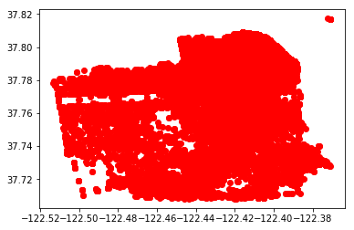

```python
# Ячейка для кода № 21
plt.plot(SF['X'],SF['Y'], 'ro')
plt.show()
```

[figure not shown]

```python
#plt.plot(SF['X'],SF['Y'], 'bo') # мой вариант цвета
#plt.show()
```

b) Определите количество полицейских районов, затем создайте словарь *pd_districts*, чтобы связать их строки с целым числом1

```python
# Ячейка для кода № 22
pd_districts = np.unique(SF['PdDistrict'])
pd_districts_levels = dict(zip(pd_districts, range(len(pd_districts)))) #объединение в словарь
pd_districts_levels
```

```
{'BAYVIEW': 0,
 'CENTRAL': 1,
 'INGLESIDE': 2,
 'MISSION': 3,
 'NORTHERN': 4,
 'PARK': 5,
 'RICHMOND': 6,
 'SOUTHERN': 7,
 'TARAVAL': 8,
 'TENDERLOIN': 9}
```

c) Используйте `apply` и `lambda`, чтобы добавить id полицейского департамента в новый столбец кадра данных.

```python
# Ячейка для кода № 23
SF['PdDistrictCode'] = SF['PdDistrict'].apply(lambda row: pd_districts_levels[row]) #добавили новый столбец в таблицу
SF
```

|  | Category | Descript | DayOfWeek | Date | Time | PdDistrict | Resolution | Address | X | Y | Month | Day | PdDistrictCode |
| --- | --- | --- | --- | --- | --- | --- | --- | --- | --- | --- | --- | --- | --- |
| 0 | LARCENY/THEFT | GRAND THEFT FROM UNLOCKED AUTO | Sunday | 08/31/2014 07:00:00 AM +0000 | 20:30 | CENTRAL | NONE | HYDE ST / CALIFORNIA ST | -122.417393 | 37.790974 | 8 | 31 | 1 |
| 1 | LARCENY/THEFT | GRAND THEFT FROM LOCKED AUTO | Sunday | 08/31/2014 07:00:00 AM +0000 | 14:30 | CENTRAL | NONE | COLUMBUS AV / JACKSON ST | -122.404418 | 37.796302 | 8 | 31 | 1 |
| 2 | LARCENY/THEFT | GRAND THEFT FROM LOCKED AUTO | Sunday | 08/31/2014 07:00:00 AM +0000 | 11:30 | CENTRAL | NONE | SUTTER ST / STOCKTON ST | -122.406959 | 37.789435 | 8 | 31 | 1 |
| 3 | DRUG/NARCOTIC | POSSESSION OF METH-AMPHETAMINE | Sunday | 08/31/2014 07:00:00 AM +0000 | 17:49 | MISSION | ARREST, BOOKED | 16TH ST / MISSION ST | -122.419672 | 37.765050 | 8 | 31 | 3 |
| 4 | DRUG/NARCOTIC | POSSESSION OF COCAINE | Sunday | 08/31/2014 07:00:00 AM +0000 | 18:05 | NORTHERN | ARREST, BOOKED | LARKIN ST / OFARRELL ST | -122.417904 | 37.785167 | 8 | 31 | 4 |
| ... | ... | ... | ... | ... | ... | ... | ... | ... | ... | ... | ... | ... | ... |
| 30755 | LARCENY/THEFT | PETTY THEFT SHOPLIFTING | Sunday | 06/01/2014 07:00:00 AM +0000 | 15:30 | SOUTHERN | ARREST, BOOKED | 900.0 Block of MARKET ST | -122.408052 | 37.783957 | 6 | 1 | 7 |
| 30756 | OTHER OFFENSES | DRIVERS LICENSE, SUSPENDED OR REVOKED | Sunday | 06/01/2014 07:00:00 AM +0000 | 16:00 | NORTHERN | ARREST, CITED | POLK ST / MCALLISTER ST | -122.418601 | 37.780261 | 6 | 1 | 4 |
| 30757 | ASSAULT | BATTERY | Sunday | 06/01/2014 07:00:00 AM +0000 | 15:00 | TENDERLOIN | ARREST, CITED | 0.0 Block of JONES ST | -122.412122 | 37.781379 | 6 | 1 | 9 |
| 30758 | ASSAULT | ASSAULT WITH CAUSTIC CHEMICALS | Sunday | 06/01/2014 07:00:00 AM +0000 | 15:20 | CENTRAL | NONE | 200.0 Block of GEARY ST | -122.407434 | 37.787494 | 6 | 1 | 1 |
| 30759 | OTHER OFFENSES | DRIVERS LICENSE, SUSPENDED OR REVOKED | Sunday | 06/01/2014 07:00:00 AM +0000 | 13:15 | INGLESIDE | ARREST, CITED | MISSION ST / BOSWORTH ST | -122.426391 | 37.733675 | 6 | 1 | 2 |

30760 rows × 13 columns

d) Используйте только что созданный *PdDistrictCode* для автоматического изменения цвета

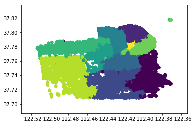

```python
# Ячейка для кода № 24
plt.scatter(SF['X'], SF['Y'], c=SF['PdDistrictCode']) #вывод по районам в зависимости от id
plt.show()
```

#### Шаг 2: добавьте пакет Map, чтобы улучшить график.

На Шаге 1 вы создали простой сюжет, который показывает, где происходили инциденты с преступностью в округе SF. Этот график полезен, но `folium` предоставляет дополнительные функции, которые позволят вам наложить этот график на карту OpenStreet.

a) `Folium` требует указания цвета маркера с использованием шестнадцатеричного значения. По этой причине мы используем пакет *colors* и выбираем необходимые цвета.

```python
# Ячейка для кода № 25
from matplotlib import colors
districts = np.unique(SF['PdDistrict'])
print(list(colors.cnames.values())[0:len(districts)]) #список части палитры цветов
```

```
['#F0F8FF', '#FAEBD7', '#00FFFF', '#7FFFD4', '#F0FFFF', '#F5F5DC', '#FFE4C4', '#000000', '#FFEBCD', '#0000FF']
```

b) Создайте цветной словарь для каждого полицейского района.

```python
# Ячейка для кода № 26
color_dict = dict(zip(districts, list(colors.cnames.values())[0:len(districts)]))  #создали словарь: район-цвет
color_dict
```

```
{'BAYVIEW': '#F0F8FF',
 'CENTRAL': '#FAEBD7',
 'INGLESIDE': '#00FFFF',
 'MISSION': '#7FFFD4',
 'NORTHERN': '#F0FFFF',
 'PARK': '#F5F5DC',
 'RICHMOND': '#FFE4C4',
 'SOUTHERN': '#000000',
 'TARAVAL': '#FFEBCD',
 'TENDERLOIN': '#0000FF'}
```

c) Создайте карту, используя средние значения координат SF Data, чтобы центрировать карту (используя `mean`). Чтобы уменьшить время вычисления, используется переменная *plotEvery* для ограничения количества построенных данных. Задайте ей значение 1, чтобы построить все строки (может потребоваться много времени, чтобы визуализировать карту).

```python
# Ячейка для кода № 27
# Создание карты
map_osm = folium.Map(location=[SF['Y'].mean(), SF['X'].mean()], zoom_start = 12)
plotEvery = 50
obs = list(zip( SF['Y'], SF['X'], SF['PdDistrict']))

for el in obs[0:-1:plotEvery]:

    folium.CircleMarker(el[0:2], color=color_dict[el[2]], fill_color=el[2],radius=10).add_to(map_osm)
#мой вариант отображение цвета отличается от исходного, потому что цвета в исходном списке таблицы цветов
```

```python
# Ячейка для кода № 28
map_osm
```

[interactive chart not shown]